# KNN Project

Etana Disasa

9/16/2019

# Introduction

This week’s project will use KNN to analyze a bank marketing data in order to determine whether a product is subscription is ‘yes’ or ‘no’. We will also examine if changing the K value changes our error rate. This data has 4521 observations. The process for this assignment will be acquiring and exploring the data, dividing the data in 8:2 ratio, perform prediction using KNN with two k-values, and finally, explain the results.

#Methods

### Acquiring and Exploring the Data

The data we are using has been downloaded and placed in the local folder as ‘bank.csv’. Because this file is semi-colon seperated data, we have used the function `read.delim` and specify the separator to read the data.

```r
MyBank <- read.delim(file = "bank.csv", sep = ";")
head(MyBank, n=5)
```

|  | age | job | marital | education | default | balance | housing | loan | contact | day | month | duration | campaign | pdays | previous | poutcome | y |
| --- | --- | --- | --- | --- | --- | --- | --- | --- | --- | --- | --- | --- | --- | --- | --- | --- | --- |
| 1 | 30 | unemployed | married | primary | no | 1787 | no | no | cellular | 19 | oct | 79 | 1 | -1 | 0 | unknown | no |
| 2 | 33 | services | married | secondary | no | 4789 | yes | yes | cellular | 11 | may | 220 | 1 | 339 | 4 | failure | no |
| 3 | 35 | management | single | tertiary | no | 1350 | yes | no | cellular | 16 | apr | 185 | 1 | 330 | 1 | failure | no |
| 4 | 30 | management | married | tertiary | no | 1476 | yes | yes | unknown | 3 | jun | 199 | 4 | -1 | 0 | unknown | no |
| 5 | 59 | blue-collar | married | secondary | no | 0 | yes | no | unknown | 5 | may | 226 | 1 | -1 | 0 | unknown | no |

It appears that the product subscription information is recorded under the column name `y`. Several variables, including `y` are factors. In order for KNN function to work, we would need to change these variables into numeric values. Therefore, we would change them as follows.

```r
MyBank$y <- as.numeric(MyBank$y)
MyBank$job <- as.numeric(MyBank$job)
MyBank$marital <- as.numeric(MyBank$marital)
MyBank$education <- as.numeric(MyBank$education)
MyBank$default <- as.numeric(MyBank$default)
MyBank$housing <- as.numeric(MyBank$housing)
MyBank$loan <- as.numeric(MyBank$loan)
MyBank$contact <- as.numeric(MyBank$contact)
MyBank$month <- as.numeric(MyBank$month)
MyBank$poutcome <- as.numeric(MyBank$poutcome)
str(MyBank)
```

```
## 'data.frame':    4521 obs. of  17 variables:
##  $ age      : int  30 33 35 30 59 35 36 39 41 43 ...
##  $ job      : num  11 8 5 5 2 5 7 10 3 8 ...
##  $ marital  : num  2 2 3 2 2 3 2 2 2 2 ...
##  $ education: num  1 2 3 3 2 3 3 2 3 1 ...
##  $ default  : num  1 1 1 1 1 1 1 1 1 1 ...
##  $ balance  : int  1787 4789 1350 1476 0 747 307 147 221 -88 ...
##  $ housing  : num  1 2 2 2 2 1 2 2 2 2 ...
##  $ loan     : num  1 2 1 2 1 1 1 1 1 2 ...
##  $ contact  : num  1 1 1 3 3 1 1 1 3 1 ...
##  $ day      : int  19 11 16 3 5 23 14 6 14 17 ...
##  $ month    : num  11 9 1 7 9 4 9 9 9 1 ...
##  $ duration : int  79 220 185 199 226 141 341 151 57 313 ...
##  $ campaign : int  1 1 1 4 1 2 1 2 2 1 ...
##  $ pdays    : int  -1 339 330 -1 -1 176 330 -1 -1 147 ...
##  $ previous : int  0 4 1 0 0 3 2 0 0 2 ...
##  $ poutcome : num  4 1 1 4 4 1 2 4 4 1 ...
##  $ y        : num  1 1 1 1 1 1 1 1 1 1 ...
```

### Divide the Data into (8:2) Ratio

```r
set.seed(60) # For academic purposes when using a pseudorandom function
MyBank$Set <- sample(c("training","test"), nrow(MyBank), replace = TRUE, prob = c(0.8, 0.2))
head(MyBank$Set, n = 10)
```

```
##  [1] "training" "training" "training" "training" "training" "training"
##  [7] "training" "test"     "training" "test"
```

```r
MyBankTraining <- subset(MyBank, Set == "training", select = 1 : 17)
MyBankTest <- subset(MyBank, Set == "test", select = 1 : 17)
nrow(MyBankTraining) + nrow(MyBankTest) # Should be 4521
```

```
## [1] 4521
```

We have **928** predictions we will be doing.

### KNN with k-value = 1

We will not set K `k = 1` for our prediction.

```r
MyPrediction <- class::knn(MyBankTraining, MyBankTest, cl = MyBankTraining$y, k =1)
MyActual <- MyBankTest$y
MyConfusionMatrix1 <- table(MyActual, MyPrediction)
MyConfusionMatrix1
```

```
##         MyPrediction
## MyActual   1   2
##        1 736  61
##        2  95  36
```

### KNN with k-value = 5

```r
MyPrediction <- class::knn(MyBankTraining, MyBankTest, cl = MyBankTraining$y, k = 5)
MyActual <- MyBankTest$y
MyConfusionMatrix2 <- table(MyActual, MyPrediction)
MyConfusionMatrix2
```

```
##         MyPrediction
## MyActual   1   2
##        1 778  19
##        2 112  19
```

### Report Error Rate

```r
MyErrorRate1 <- ((MyConfusionMatrix1[1,2] + MyConfusionMatrix1[2,1])/nrow(MyBankTest))
MyErrorRate2 <- ((MyConfusionMatrix2[1,2] + MyConfusionMatrix2[2,1])/nrow(MyBankTest))
MyError <- data.frame(KValue=c("1","5"),
                      ErrorRate=c(MyErrorRate1,MyErrorRate2)
                      )
MyError
```

| KValue | ErrorRate |
| --- | --- |
| 1 | 0.1681034 |
| 5 | 0.1411638 |

The total number of predications we made were `nrow(MyBankTest)` = 928 When K = 1, the error rate is 16.8103448%. When K = 5, the error rate drops to 14.1163793%. In other words, the error was reduced by 16.025641%.

### Plotting the Error Rate

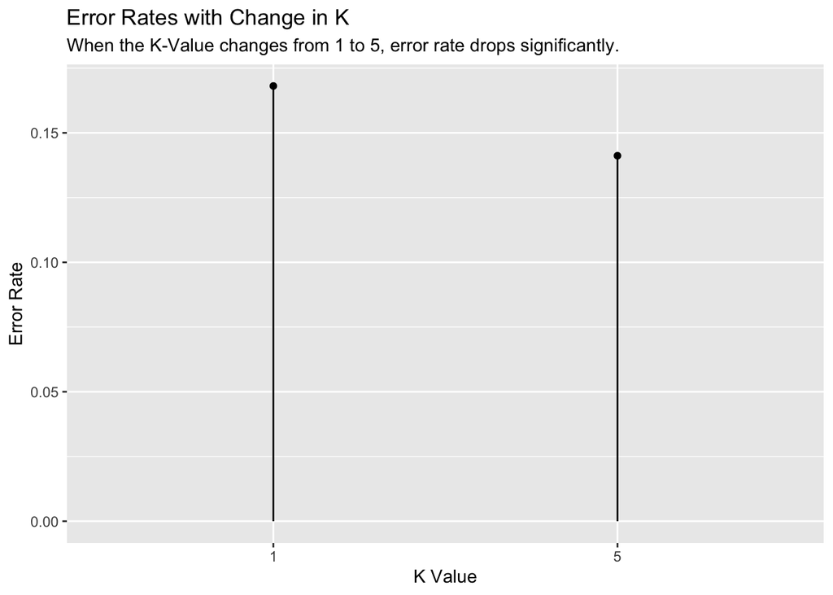

```r
ggplot(MyError, aes(x=KValue, y=ErrorRate), xlab="Etana") +
    labs(x= "K Value", y="Error Rate", title = "Error Rates with Change in K", subtitle = "When the K-Value changes from 1 to 5, error rate drops significantly.") +
    geom_point() +
    geom_segment(aes(x=KValue, xend=KValue, y=ErrorRate, yend=0))
```

# Conclusion

The plot above shows how the error rate of our prediction significanly lowers as the k-value goes from 1 to 5. As KNN does prediciton or classification using k-values (distance from a particular data point), then changing the data type to numeric value will be a necessity for variable that will be included into the prediciton process.

# References

https://ggplot2.tidyverse.org/reference/labs.html